# PubHealthEpi: Health Disparities, Survival Analysis & Causal Inference

An End-to-End Public Health Epidemiology Pipeline

Author

Ludovic Njiosseu, MS Biostatistics

Published

May 19, 2026

## Overview

This project builds a complete public health epidemiology pipeline on a simulated longitudinal cohort of 8,000 patients, integrating three analytical modules: **claims-based disparity analysis**, **survival analysis** (Kaplan-Meier + Cox PH), and **causal inference** (IPTW + Doubly Robust AIPW). It replicates methods used in regulatory-grade real-world evidence (RWE) studies and population health research.

**Research question:** Does receipt of a community health worker intervention reduce time to acute hospitalization, and does this effect persist after adjusting for confounding by insurance status, race/ethnicity, and socioeconomic factors?

## Module 1 — Data Construction

```r
source("scripts/01_simulate_data.R")
```

```
Cohort: 8000 patients | Event rate: 82.9% | Median follow-up: 29.3 months
Intervention rate: 28.1%
Claims: 21157 records across 7808 patients
Saved: data/cohort.csv, data/claims.csv
```

```r
library(tidyverse)
library(survival)
```

The cohort includes patients enrolled 2015–2019 with up to 60 months of follow-up. Key features: demographics, insurance type, poverty area percentage, comorbidity burden (Charlson index), smoking status, BMI, and a binary intervention indicator subject to confounding (intervention uptake is higher among insured and urban patients — a realistic selection mechanism).

## Module 2 — Claims-Based Disparity Analysis

```r
source("scripts/02_disparity_analysis.R")
```

```
--- ED Utilization by Race/Ethnicity ---
# A tibble: 5 × 5
  race_ethnicity     n pct_any_ed avg_ed_visits avg_ed_cost
  <chr>          <int>      <dbl>         <dbl>       <dbl>
1 Asian            784       86.5          3.64        6566
2 Other            538       86.1          3.63        6584
3 Hispanic        1610       85.8          3.51        6336
4 White           3356       85.1          3.54        6374
5 Black           1712       82.7          3.36        6111

--- ED Utilization by Insurance Type ---
# A tibble: 4 × 5
  insurance_type     n pct_any_ed avg_ed_visits avg_ed_cost
  <chr>          <int>      <dbl>         <dbl>       <dbl>
1 Uninsured       1101       88.1          3.88        6969
2 Medicaid        1765       87.6          4.14        7533
3 Private         3569       83.9          3.29        5930
4 Medicare        1565       82.2          3.04        5501

--- Primary Care Access Gap (% with <2 visits) ---
# A tibble: 15 × 5
   race_ethnicity insurance_type     n pct_low_pc_use avg_pc_per_yr
   <chr>          <chr>          <int>          <dbl>         <dbl>
 1 Black          Uninsured        246          33.3           1.99
 2 Other          Uninsured         83          26.5           1.93
 3 White          Uninsured        474          22.4           2.08
 4 Hispanic       Uninsured        211          19.9           2.11
 5 Asian          Uninsured         87          19.5           2.14
 6 Black          Medicaid         381          15.2           3.1
 7 Black          Medicare         351          14.8           3.23
 8 Asian          Medicaid         167          13.8           3.25
 9 Asian          Medicare         158          13.3           3.13
10 Hispanic       Medicare         296          12.5           3.28
11 White          Medicaid         759          12.1           3.21
12 White          Medicare         655          11.6           3.37
13 Hispanic       Medicaid         353          11.3           3.05
14 Other          Medicaid         105           9.52          3.15
15 Other          Medicare         105           9.52          3.24

--- ED Overutilization: Adjusted Odds Ratios ---
# A tibble: 10 × 4
   variable       log_odds odds_ratio p_value
   <chr>             <dbl>      <dbl>   <dbl>
 1 uninsured        0.390       1.48   0.0001
 2 medicaid         0.344       1.41   0
 3 poverty_pct     -0.289       0.749  0.0083
 4 current_smoker  -0.261       0.771  0.0006
 5 black           -0.227       0.797  0.0032
 6 charlson_index   0.185       1.20   0
 7 intervention    -0.120       0.887  0.0919
 8 hispanic         0.0309      1.03   0.710
 9 rural           -0.0148      0.985  0.849
10 age             -0.0127      0.987  0

Disparity analysis complete. Outputs saved to outputs/
```

### ED Utilization by Race/Ethnicity

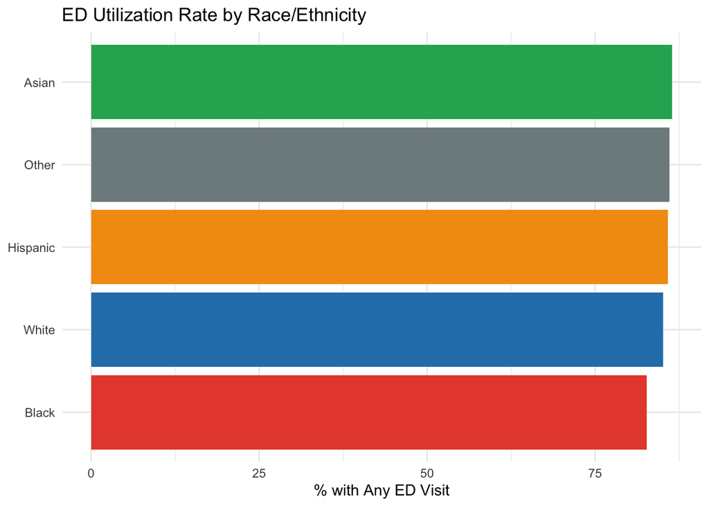

```r
ed_race <- read_csv("outputs/ed_by_race.csv", show_col_types = FALSE)
ed_race %>%
  mutate(race_ethnicity = fct_reorder(race_ethnicity, pct_any_ed)) %>%
  ggplot(aes(x = race_ethnicity, y = pct_any_ed, fill = race_ethnicity)) +
  geom_col() + coord_flip() +
  scale_fill_manual(values = c(White = "#2980b9", Black = "#e74c3c",
                               Hispanic = "#f39c12", Asian = "#27ae60",
                               Other = "#7f8c8d")) +
  labs(title = "ED Utilization Rate by Race/Ethnicity",
       x = NULL, y = "% with Any ED Visit") +
  theme_minimal() + theme(legend.position = "none")
```

### Adjusted Predictors of ED Overutilization

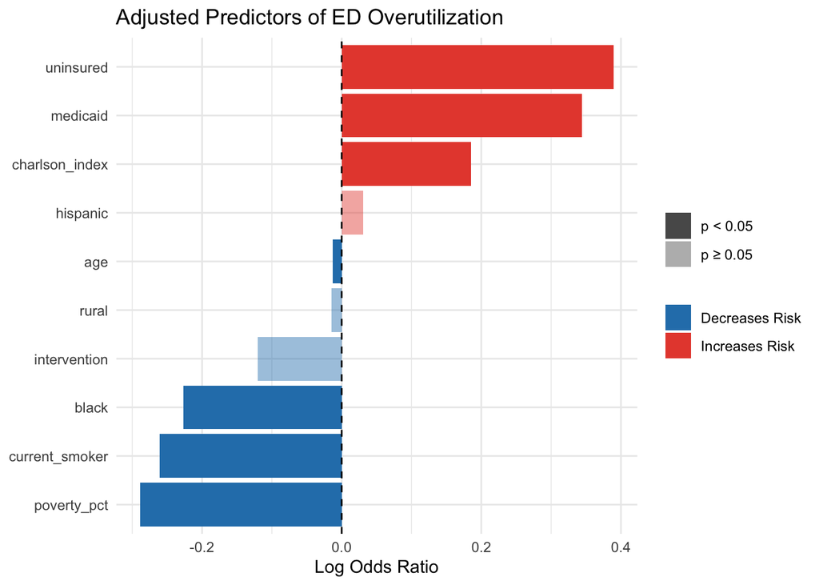

```r
ed_logit <- read_csv("outputs/ed_logistic_regression.csv", show_col_types = FALSE)
ed_logit %>%
  mutate(variable  = fct_reorder(variable, odds_ratio),
         direction = ifelse(odds_ratio > 1, "Increases Risk", "Decreases Risk"),
         sig       = ifelse(p_value < 0.05, "p < 0.05", "p ≥ 0.05")) %>%
  ggplot(aes(x = variable, y = log(odds_ratio), fill = direction, alpha = sig)) +
  geom_col() + coord_flip() +
  geom_hline(yintercept = 0, linetype = "dashed") +
  scale_fill_manual(values = c("Increases Risk" = "#e74c3c",
                               "Decreases Risk" = "#2980b9")) +
  scale_alpha_manual(values = c("p < 0.05" = 1, "p ≥ 0.05" = 0.45)) +
  labs(title = "Adjusted Predictors of ED Overutilization",
       x = NULL, y = "Log Odds Ratio", fill = NULL, alpha = NULL) +
  theme_minimal()
```

## Module 3 — Survival Analysis

```r
source("scripts/03_survival_analysis.R")
```

```
Log-rank test — Intervention: chi² = 240.520, p = 0.0000
Log-rank test — Insurance:     chi² = 348.438, p = 0.0000
Log-rank test — Race/Ethnicity: chi² = 20.522, p = 0.0004

--- Cox PH Model: Hazard Ratios ---
# A tibble: 15 × 7
   variable          coef    hr hr_lower95 hr_upper95 p_value significant
   <chr>            <dbl> <dbl>      <dbl>      <dbl>   <dbl> <chr>
 1 intervention   -0.349  0.706      0.666      0.748  0      "*"
 2 rural          -0.0294 0.971      0.912      1.03   0.361  ""
 3 asian          -0.0047 0.995      0.914      1.08   0.914  ""
 4 suburban       -0.0041 0.996      0.941      1.05   0.886  ""
 5 bmi             0.0062 1.01       1.00       1.01   0.0054 "*"
 6 age_centered    0.0139 1.01       1.01       1.02   0      "*"
 7 hispanic        0.0371 1.04       0.974      1.11   0.256  ""
 8 charlson_index  0.0765 1.08       1.06       1.10   0      "*"
 9 former_smoker   0.113  1.12       1.06       1.18   0.0001 "*"
10 black           0.146  1.16       1.09       1.23   0      "*"
11 medicare        0.222  1.25       1.17       1.33   0      "*"
12 poverty_pct     0.231  1.26       1.16       1.37   0      "*"
13 medicaid        0.249  1.28       1.20       1.37   0      "*"
14 current_smoker  0.336  1.40       1.31       1.49   0      "*"
15 uninsured       0.613  1.85       1.72       1.99   0      "*"

Concordance (C-index): 0.6038
Likelihood ratio test p-value: 4.2027e-188

--- Proportional Hazards Assumption Test ---
# A tibble: 16 × 4
   variable         chisq p_value ph_holds
   <chr>            <dbl>   <dbl> <chr>
 1 intervention    0.0656  0.798  Yes
 2 uninsured      10.5     0.0012 Violation
 3 medicaid        0.0094  0.923  Yes
 4 medicare        0.0158  0.900  Yes
 5 black           0.333   0.564  Yes
 6 hispanic        0.0831  0.773  Yes
 7 asian           1.22    0.268  Yes
 8 rural           0.752   0.386  Yes
 9 suburban        0.329   0.566  Yes
10 poverty_pct     0.285   0.593  Yes
11 charlson_index  0.900   0.343  Yes
12 age_centered    0.252   0.615  Yes
13 current_smoker  0.458   0.499  Yes
14 former_smoker   2.02    0.156  Yes
15 bmi             0.424   0.515  Yes
16 GLOBAL         18.8     0.222  Yes

Survival analysis complete.
```

### Kaplan-Meier: Intervention vs Control

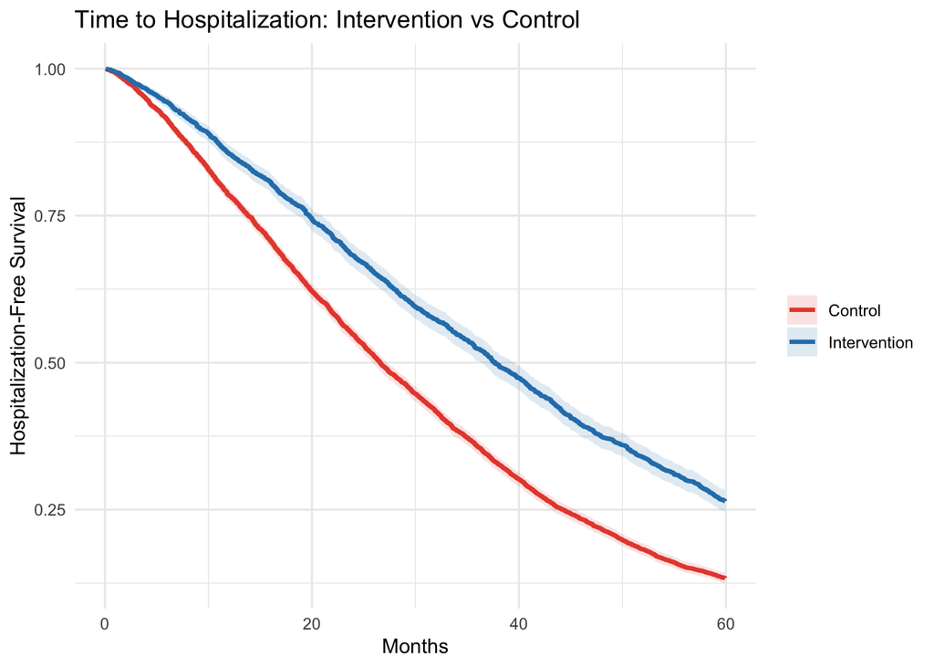

```r
km_int <- read_csv("outputs/km_intervention.csv", show_col_types = FALSE)
km_int %>%
  mutate(Group = ifelse(strata == "intervention=0", "Control", "Intervention")) %>%
  ggplot(aes(x = time, y = survival, color = Group, fill = Group)) +
  geom_step(size = 1.1) +
  geom_ribbon(aes(ymin = lower, ymax = upper), alpha = 0.15, color = NA) +
  scale_color_manual(values = c(Control = "#e74c3c", Intervention = "#2980b9")) +
  scale_fill_manual(values  = c(Control = "#e74c3c", Intervention = "#2980b9")) +
  labs(title = "Time to Hospitalization: Intervention vs Control",
       x = "Months", y = "Hospitalization-Free Survival",
       color = NULL, fill = NULL) +
  theme_minimal()
```

### Cox Proportional Hazards Model

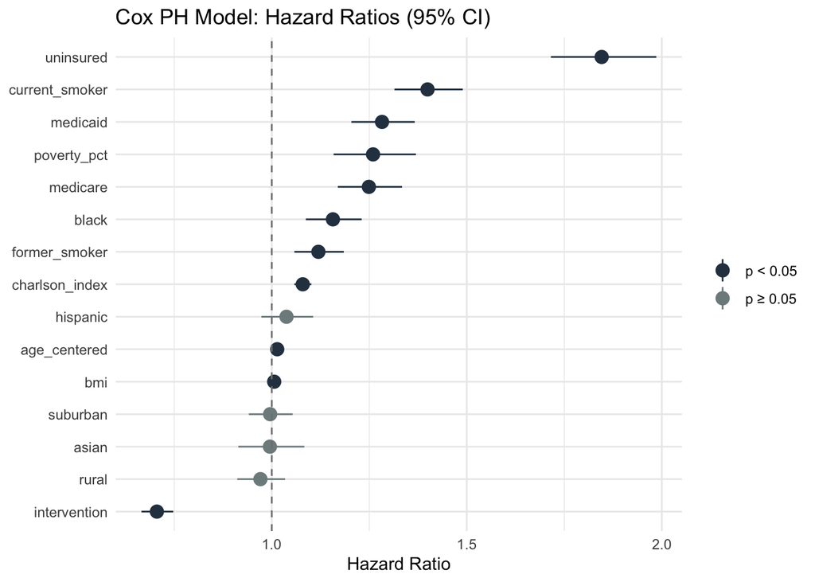

```r
cox_results <- read_csv("outputs/cox_results.csv", show_col_types = FALSE)
cox_results %>%
  mutate(variable = fct_reorder(variable, hr),
         sig      = ifelse(p_value < 0.05, "p < 0.05", "p ≥ 0.05")) %>%
  ggplot(aes(x = variable, y = hr, ymin = hr_lower95, ymax = hr_upper95,
             color = sig)) +
  geom_pointrange(size = 0.7) +
  geom_hline(yintercept = 1, linetype = "dashed", color = "grey50") +
  coord_flip() +
  scale_color_manual(values = c("p < 0.05" = "#2c3e50", "p ≥ 0.05" = "#7f8c8d")) +
  labs(title = "Cox PH Model: Hazard Ratios (95% CI)",
       x = NULL, y = "Hazard Ratio", color = NULL) +
  theme_minimal()
```

```r
cox_metrics <- read_csv("outputs/cox_model_metrics.csv", show_col_types = FALSE)
knitr::kable(cox_metrics, caption = "Cox Model Fit Statistics")
```

Cox Model Fit Statistics

| metric | value |
| --- | --- |
| C-index (Concordance) | 0.6038 |
| Log-Likelihood | -54938.5900 |
| AIC | 109907.1800 |
| N events | 6634.0000 |

The proportional hazards assumption was tested via Schoenfeld residuals (see `outputs/ph_test.csv`).

## Module 4 — Causal Inference (IPTW + AIPW)

```r
source("scripts/04_causal_inference.R")
```

```
Propensity score range: 0.027 – 0.558 | Mean: 0.281

--- Propensity Score Overlap ---
# A tibble: 2 × 4
  intervention min_ps max_ps mean_ps
         <dbl>  <dbl>  <dbl>   <dbl>
1            0  0.027  0.558   0.26
2            1  0.038  0.553   0.336

IPTW (stabilized, trimmed) range: 0.509 – 2.668 | Mean: 0.992

--- Covariate Balance (SMD) ---
# A tibble: 10 × 4
   variable       smd_unadjusted smd_iptw balance_achieved
   <chr>                   <dbl>    <dbl> <lgl>
 1 uninsured             -0.425   -0.0684 TRUE
 2 medicaid              -0.228    0.0083 TRUE
 3 medicare               0.162    0.014  TRUE
 4 black                 -0.0071  -0.0045 TRUE
 5 hispanic               0        0.0047 TRUE
 6 rural                 -0.260   -0.022  TRUE
 7 poverty_pct           -0.227   -0.0113 TRUE
 8 charlson_index         0.0476   0.0112 TRUE
 9 age_centered          -0.124   -0.0052 TRUE
10 bmi                   -0.0159   0.0049 TRUE
Variables achieving balance (|SMD| < 0.10): 10 / 10

IPTW ATE: -0.0997 (75.9% treated vs 85.9% control) | RR: 0.884
Bootstrap 95% CI: [-0.1211, -0.0785]

AIPW ATE: -0.0938 | 95% CI: [-0.1142, -0.0734]
E-value: 1.517 (unmeasured confounder association with treatment AND outcome must both exceed 1.52 to explain away effect)

--- Causal Estimates Summary ---
# A tibble: 3 × 4
  estimator                ate ci_lower ci_upper
  <chr>                  <dbl>    <dbl>    <dbl>
1 Unadjusted           -0.131    NA      NA
2 IPTW                 -0.0997   -0.121  -0.0785
3 AIPW (Doubly Robust) -0.0938   -0.114  -0.0734

Causal inference analysis complete.
```

### Propensity Score Overlap

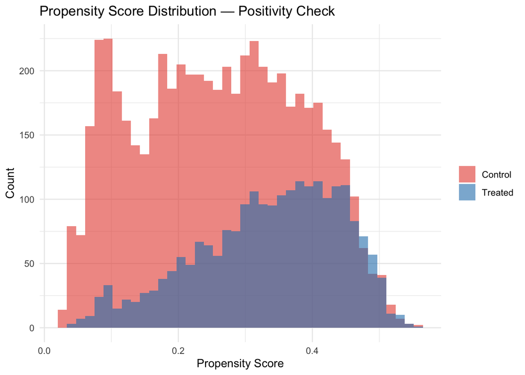

```r
ps <- read_csv("outputs/propensity_scores.csv", show_col_types = FALSE)
ps %>%
  mutate(Group = ifelse(intervention == 1, "Treated", "Control")) %>%
  ggplot(aes(x = ps, fill = Group)) +
  geom_histogram(bins = 40, alpha = 0.6, position = "identity") +
  scale_fill_manual(values = c(Treated = "#2980b9", Control = "#e74c3c")) +
  labs(title = "Propensity Score Distribution — Positivity Check",
       x = "Propensity Score", y = "Count", fill = NULL) +
  theme_minimal()
```

### Covariate Balance Before and After IPTW

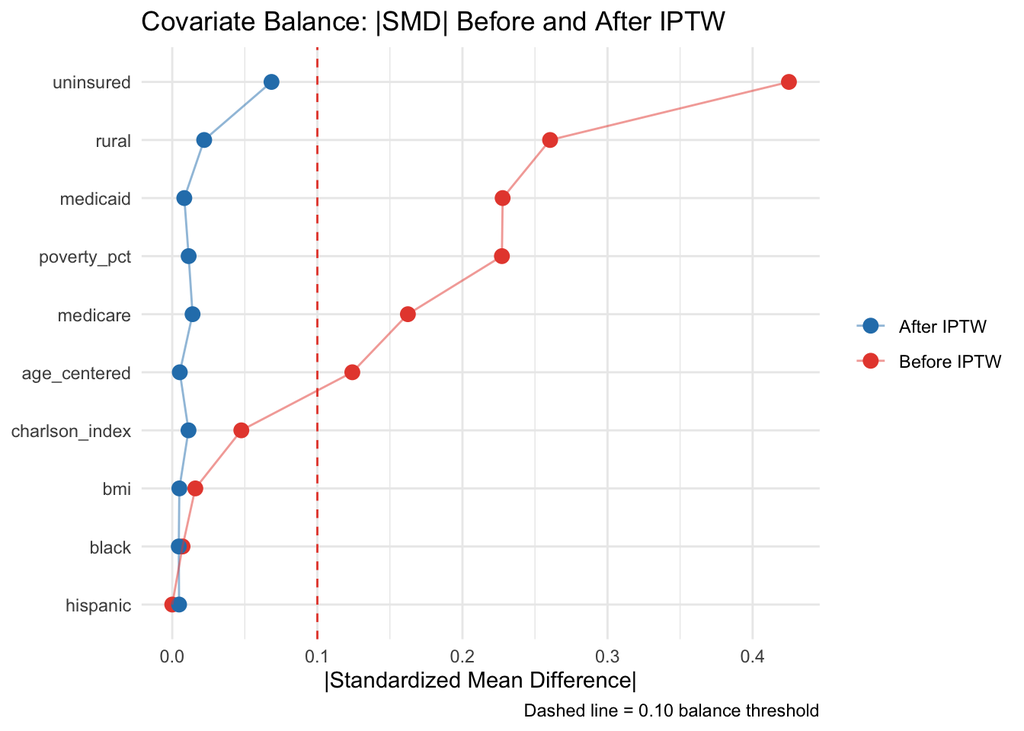

```r
balance <- read_csv("outputs/covariate_balance.csv", show_col_types = FALSE)
balance %>%
  mutate(variable = fct_reorder(variable, abs(smd_unadjusted))) %>%
  pivot_longer(cols = c(smd_unadjusted, smd_iptw),
               names_to = "type", values_to = "smd") %>%
  mutate(type = ifelse(type == "smd_unadjusted", "Before IPTW", "After IPTW")) %>%
  ggplot(aes(x = variable, y = abs(smd), color = type, group = type)) +
  geom_point(size = 3) + geom_line(alpha = 0.5) + coord_flip() +
  geom_hline(yintercept = 0.10, linetype = "dashed", color = "#e74c3c") +
  scale_color_manual(values = c("Before IPTW" = "#e74c3c", "After IPTW" = "#2980b9")) +
  labs(title = "Covariate Balance: |SMD| Before and After IPTW",
       x = NULL, y = "|Standardized Mean Difference|", color = NULL,
       caption = "Dashed line = 0.10 balance threshold") +
  theme_minimal()
```

### Causal Estimates Comparison

```r
causal <- read_csv("outputs/causal_estimates.csv", show_col_types = FALSE)
knitr::kable(causal, caption = "ATE: Unadjusted vs IPTW vs AIPW")
```

ATE: Unadjusted vs IPTW vs AIPW

| estimator | ate | ci_lower | ci_upper |
| --- | --- | --- | --- |
| Unadjusted | -0.1308 | NA | NA |
| IPTW | -0.0997 | -0.1211 | -0.0785 |
| AIPW (Doubly Robust) | -0.0938 | -0.1142 | -0.0734 |

```r
causal_kpi <- read_csv("outputs/causal_key_metrics.csv", show_col_types = FALSE)
knitr::kable(causal_kpi, caption = "Key Causal Inference Metrics")
```

Key Causal Inference Metrics

| metric | value |
| --- | --- |
| ATE (AIPW) | -0.0938 |
| 95% CI Lower | -0.1142 |
| 95% CI Upper | -0.0734 |
| E-value | 1.517 |
| Variables balanced (\|SMD\|<0.10) | 10/10 |

The doubly robust AIPW estimator provides consistent ATE estimates as long as either the propensity score model or the outcome model is correctly specified. The E-value quantifies robustness to unmeasured confounding: an unmeasured confounder would need to be associated with both treatment and outcome by a factor exceeding the E-value to fully explain away the estimated effect.

## Reproducibility

```r
install.packages(c("tidyverse", "survival", "shiny", "bslib", "bsicons", "DT"))

source("scripts/01_simulate_data.R")
source("scripts/02_disparity_analysis.R")
source("scripts/03_survival_analysis.R")
source("scripts/04_causal_inference.R")

shiny::runApp("shiny/")
quarto::quarto_render("pubhealth_report.qmd")
```

## Limitations & Extensions

- Data is simulated; real-world application requires claims linkage, IRB approval, and data use agreements.
- Cox model assumes proportional hazards; violations for any covariate are flagged via Schoenfeld test and would warrant time-varying coefficient models.
- IPTW assumes no unmeasured confounding (conditional exchangeability); the E-value provides sensitivity analysis but does not eliminate this limitation.
- Competing risks (e.g. death before hospitalization) are not modeled; Fine-Gray subdistribution hazard models are the appropriate extension.
- Area-level poverty is used as a proxy for SES; individual-level income, education, and housing data would improve precision.